# Quantitative notions of relevance: Data analysis for ‘Relevance Only’

Author

Alex Warstadt, Omar Aghar & Michael Franke

First load required packages and set some global parameters.

```r
library(tidyverse)
library(brms)
library(tidyboot)
library(tidyjson)
library(patchwork)
library(GGally)
library(cowplot)
library(BayesFactor)
library(aida)   # custom helpers: https://github.com/michael-franke/aida-package
library(faintr) # custom helpers: https://michael-franke.github.io/faintr/index.html
library(cspplot) # custom styles: https://github.com/CogSciPrag/cspplot
library(ordbetareg) # for ordered beta-regression
library(cmdstanr)

##################################################

# these options help Stan run faster
options(mc.cores = parallel::detectCores(),
        brms.backend = "cmdstanr")

# use the CSP-theme for plotting
theme_set(theme_csp())

# global color scheme from CSP
project_colors = cspplot::list_colors() |> pull(hex)

# setting theme colors globally
scale_colour_discrete <- function(...) {
  scale_colour_manual(..., values = project_colors)
}
scale_fill_discrete <- function(...) {
  scale_fill_manual(..., values = project_colors)
}

##################################################

rerun_models <- TRUE

Lambert_test <- function(loo_comp) {
  1 - pnorm(-loo_comp[2,1], loo_comp[2,2])
}

##################################################

rl_file <- "R_data_4_TeX/myvars-relevanceOnly.csv"
myvars = list()
# add with: myvars[name] = value
```

# This block is not necessary for all, but may be necessary for some installations of `faintr`

```r
source('xx-faintr_functions.R')
source('xx-faintr_helpers.R')
```

# Observation: bad performance in relevance-only study

In previous analyses we strictly ruled out participants with attention and reasoning scores not equal to one. This is severe for the new data, as it would reduce the number of participants from 151 to just 56.

I’m here including an analysis for slightly less strict filtering, allowing also participants with `reasoning_score == 0.5` to be included in the analysis. Without this, the final model comparison in terms of `loo` is non-significant, which is then probably due to the small sample size for the ‘relevance-only’ experiment.

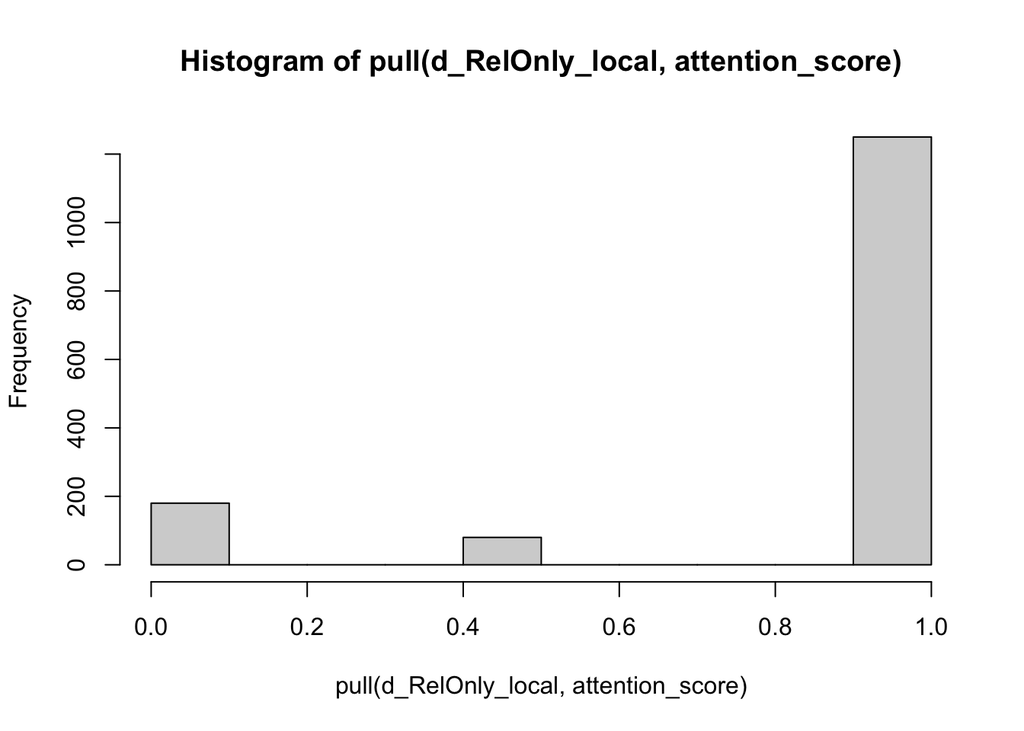

```r
# inspect the distribution of reasoning & attention scores
d_RelOnly_local <- read_csv("../results/relevance-only/results_preprocessed.csv")
d_RelOnly_local |> pull(attention_score) |> hist()
```

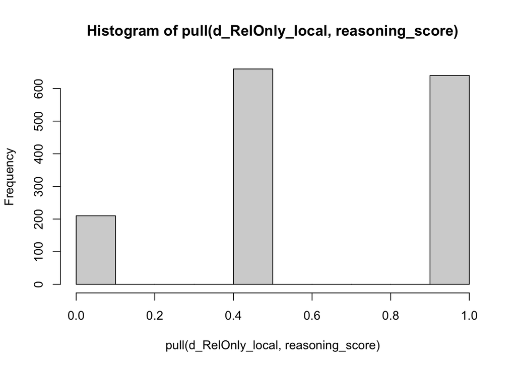

```r
d_RelOnly_local |> pull(reasoning_score) |> hist()
```

# Read & massage the data

Load raw data and preprocess it.

```r
# data from the full experiment
d_FullExp <- read_csv("../results/round_2.0/results_preprocessed.csv") |>
  # drop column with numbers
  select(-`...1`) |>
  # data exclusion based on attention & reasoning score (279 before | 235 after)
  filter(attention_score == 1) |>
  filter(reasoning_score >= 0.5) |>
  # set "non-answers" to AnswerPolarity "positive"
  mutate(AnswerPolarity = ifelse(
    AnswerCertainty == "non_answer",
    "positive",
    AnswerPolarity)) |>
  # casting into factor
  mutate(
    group = factor(group, levels = c("relevant", "helpful")),
    ContextType = factor(ContextType,
                         levels = c("negative", "neutral", "positive")),
    AnswerPolarity = factor(AnswerPolarity,
                            levels = c("positive", "negative")),
    AnswerCertainty = factor(AnswerCertainty,
                             levels = c("non_answer", "low_certainty",
                                        "high_certainty", "exhaustive"))
  ) |>
  rename(sliderResponse = relevance_sliderResponse) |>
  mutate(ExperimentType = "FullExp") |>
  select(submission_id, ExperimentType, group, StimID,
         ContextType, AnswerPolarity, AnswerCertainty, sliderResponse)

# data from the relevance only replication
d_RelOnly <- read_csv("../results/relevance-only/results_preprocessed.csv") |>
  # drop column with numbers
  select(-`...1`) |>
  # data exclusion based on attention & reasoning score (151 before | 56 after)
  filter(attention_score == 1) |>
  filter(reasoning_score >= 0.5) |>
  # set "non-answers" to AnswerPolarity "positive"
  mutate(AnswerPolarity = ifelse(
    AnswerCertainty == "non_answer",
    "positive",
    AnswerPolarity)) |>
  # casting into factor
  mutate(
    group = factor(group, levels = c("relevant", "helpful")),
    ContextType = factor(ContextType,
                         levels = c("negative", "neutral", "positive")),
    AnswerPolarity = factor(AnswerPolarity,
                            levels = c("positive", "negative")),
    AnswerCertainty = factor(AnswerCertainty,
                             levels = c("non_answer", "low_certainty",
                                        "high_certainty", "exhaustive"))
  ) |>
  mutate(ExperimentType = "RelOnly") |>
  select(submission_id, ExperimentType, group, StimID,
         ContextType, AnswerPolarity, AnswerCertainty, sliderResponse)

# combined data from both experiments
d_AllData <- bind_rows(d_FullExp, d_RelOnly)
```

# Ploting the distribution of relevance ratings

Below are plots for the density distribution of slider ratings for the positive vs. negative answer types seperately (so we can directly compare the distribution in each experiment).

[figure not shown]

```r
plot_positive <- d_AllData |>
  filter(AnswerPolarity == "positive") |>
  mutate(AnswerCertainty = case_when(AnswerCertainty == "low_certainty" ~ "low",
                                     AnswerCertainty == "high_certainty" ~ "high",
                                     AnswerCertainty == "non_answer" ~ "non-answer",
                                     TRUE ~ "exhaustive",
  ) |> factor(level = c("non-answer", "low", "high","exhaustive"))) |>
  ggplot(aes(x = sliderResponse, color = ExperimentType, fill = ExperimentType)) +
  facet_grid(AnswerCertainty ~ ContextType , scales = "free") +
  # histogram with dodged bars
  geom_density(alpha = 0.2, linewidth = 1.5) +
  xlab("relevance rating") + ylab("") +
  ggtitle("AnswerPolarity: positive")

plot_negative <- d_AllData |>
  filter(AnswerPolarity == "negative") |>
  mutate(AnswerCertainty = case_when(AnswerCertainty == "low_certainty" ~ "low",
                                     AnswerCertainty == "high_certainty" ~ "high",
                                     AnswerCertainty == "non_answer" ~ "non-answer",
                                     TRUE ~ "exhaustive",
  ) |> factor(level = c("non-answer", "low", "high","exhaustive"))) |>
  ggplot(aes(x = sliderResponse, color = ExperimentType, fill = ExperimentType)) +
  facet_grid(AnswerCertainty ~ ContextType, scales = "free") +
  geom_density(alpha = 0.2, linewidth = 1.5) +
  xlab("relevance rating") + ylab("") +
  ggtitle("AnswerPolarity: negative")


plot_positive / plot_negative
```

# Model fitting

We fit two models, one with and one without the factor `ExperimentType`. When the factor is included, it is included together with all of its interactions.

There’s a flag for function `fit_model` to refit the model or use a locally cached version. Each model fit may take up to 30 minutes or more.

```r
## fit ordinal beta-regression models ----

fit_model <- function(d, model_name, refit = T, withExpVariable = F) {

  # brms formula: whether to use 'ExperimentType' as predictor or not
  if (withExpVariable) {
    formula = brms::brmsformula(
      sliderResponse ~ ContextType * AnswerCertainty * AnswerPolarity * ExperimentType +
        (1 + ContextType + AnswerCertainty + AnswerPolarity || StimID) +
        (1 + ContextType + AnswerCertainty + AnswerPolarity || submission_id)
    )
  } else {
    formula = brms::brmsformula(
      sliderResponse ~ ContextType * AnswerCertainty * AnswerPolarity +
        (1 + ContextType + AnswerCertainty + AnswerPolarity || StimID) +
        (1 + ContextType + AnswerCertainty + AnswerPolarity || submission_id)
    )
  }

  # model name for saving
  model_name_expanded <- paste0("cachedModels-round2/exploration-RelOnly-",model_name,".Rds")

  # fitting or retrieving cached models
  if (refit) {
    fit <- ordbetareg::ordbetareg(
      formula = formula,
      data = d,
      coef_prior_SD = 5,
      save_pars = save_pars(all=TRUE)
    )
    saveRDS(fit, model_name_expanded)
  } else{
    fit <- readRDS(model_name_expanded)
  }
  return(fit)
}

fit_AllData_smpl <- fit_model(d_AllData, model_name = "AllData_smpl", refit = F, withExpVariable = F)
fit_AllData_cmpl <- fit_model(d_AllData, model_name = "AllData_cmpl", refit = F, withExpVariable = T)
```

# Coefficient-based testing

To address the question of differences between experiment, we can test whether the main effect of `ExperimentType` under deviation coding of the categorical factors (sum coding).

It turns out that the posterior probability of a main effect of `ExperimentType` is credibly different from zero, suggesting a difference between experiments as such.

```r
faintr::compare_groups(
  fit = fit_AllData_cmpl,
  higher = ExperimentType == "FullExp")
```

```
Outcome of comparing groups:
 * higher:  ExperimentType == "FullExp"
 * lower:   grand mean
Mean 'higher - lower':  0.1885
95% HDI:  [ 0.1288 ; 0.2501 ]
P('higher - lower' > 0):  1
Posterior odds:  Inf
```

NB: We could also compare the two experiments for each triple of explanatory factors `AnswerPolarity`, `AnswerCertainty` and `ContextType`. But this may be overkill.

# Model comparison

We use `loo`-based model comparison to test whether the factor `ExperimentType` is relevant for leave-one-out posterior predictive model checking. If the difference between posterior predictive accuracy is significant, we may interpret this as saying that the distribution of relevance judgements is different between experiments.

```r
rerun_loo <- F

if (rerun_loo) {
  loo_comp <- loo::loo_compare(
    list("w/o_ExpVariable" = loo(fit_AllData_smpl),
         # moment_match = TRUE,
         # reloo = TRUE),
         "w/_ExpVariable" = loo(fit_AllData_cmpl)))
  saveRDS(loo_comp, "cachedModels-round2/exploration-RelOnly-loo_comp_groups.Rds")
} else {
  loo_comp = read_rds("cachedModels-round2/exploration-RelOnly-loo_comp_groups.Rds")
}
loo_comp
```

```
                elpd_diff se_diff
w/_ExpVariable    0.0       0.0
w/o_ExpVariable -33.7      12.1
```

```r
Lambert_test(loo_comp)
```

```
[1] 0
```

Indeed, when using a more lenient exclusion criterion, we find a significant difference, so lending credence to the claim that relevance judgements were different between experiments.

# Saving variables for LaTeX